# Майнор "Интеллектуальный анализ данных"

#### 2. Поиск выбросов

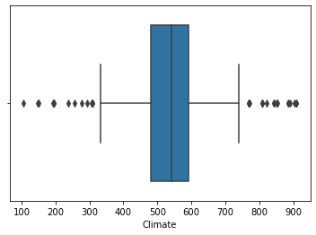

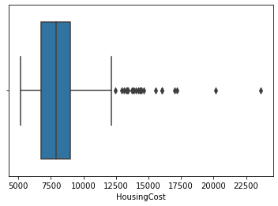

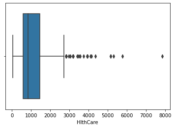

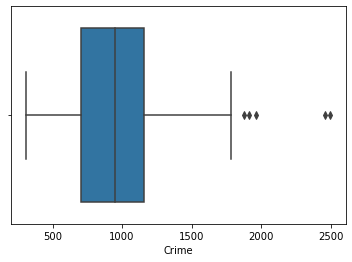

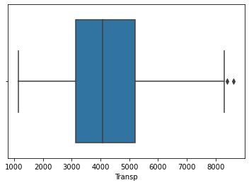

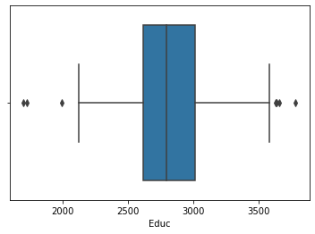

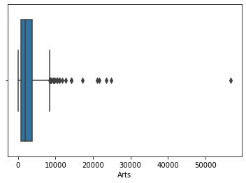

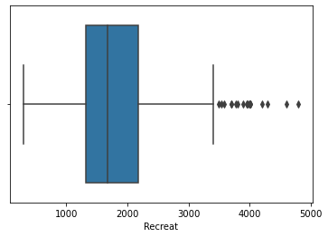

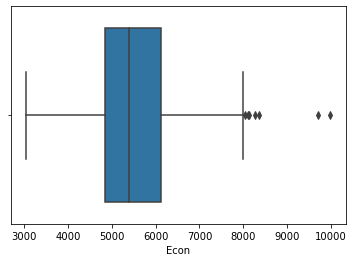

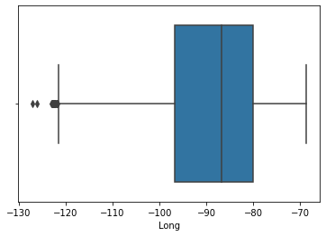

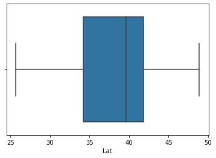

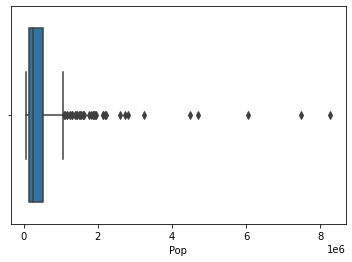

```python
col = list(data)[1:]
for c in col:
    sns.boxplot(x = data[c])
    plt.show()
```

#### 2. Стандартизация данных

```python
names_col = list(data)
del_names = ['Place', 'Long', 'Lat']
for name in del_names:
    names_col.remove(name)
data = data[names_col]
data
```

|  | Climate | HousingCost | HlthCare | Crime | Transp | Educ | Arts | Recreat | Econ | Pop |
| --- | --- | --- | --- | --- | --- | --- | --- | --- | --- | --- |
| 0 | 521 | 6200 | 237 | 923 | 4031 | 2757 | 996 | 1405 | 7633 | 110932 |
| 1 | 575 | 8138 | 1656 | 886 | 4883 | 2438 | 5564 | 2632 | 4350 | 660328 |
| 2 | 468 | 7339 | 618 | 970 | 2531 | 2560 | 237 | 859 | 5250 | 112402 |
| 3 | 476 | 7908 | 1431 | 610 | 6883 | 3399 | 4655 | 1617 | 5864 | 835880 |
| 4 | 659 | 8393 | 1853 | 1483 | 6558 | 3026 | 4496 | 2612 | 5727 | 419700 |
| ... | ... | ... | ... | ... | ... | ... | ... | ... | ... | ... |
| 324 | 562 | 8715 | 1805 | 680 | 3643 | 3299 | 1784 | 910 | 5040 | 402918 |
| 325 | 535 | 6440 | 317 | 1106 | 3731 | 2491 | 996 | 2140 | 4986 | 172508 |
| 326 | 540 | 8371 | 713 | 440 | 2267 | 2903 | 1022 | 842 | 4946 | 381255 |
| 327 | 570 | 7021 | 1097 | 938 | 3374 | 2920 | 2797 | 1327 | 3894 | 531350 |
| 328 | 608 | 7875 | 212 | 1179 | 2768 | 2387 | 122 | 918 | 4694 | 101979 |

329 rows × 10 columns

```python
from sklearn.preprocessing import MinMaxScaler
```

```python
minmax = MinMaxScaler()
data_transformed = minmax.fit_transform(data)
data_transformed
```

```
array([[0.51677019, 0.05632812, 0.02484949, ..., 0.24555556, 0.66157174,
        0.00585864],
       [0.58385093, 0.16119258, 0.20660945, ..., 0.51822222, 0.18817592,
        0.0727591 ],
       [0.45093168, 0.11795898, 0.07365185, ..., 0.12422222, 0.31795242,
        0.00603765],
       ...,
       [0.54037267, 0.17380012, 0.08582042, ..., 0.12044444, 0.2741168 ,
        0.03877612],
       [0.57763975, 0.10075212, 0.13500704, ..., 0.22822222, 0.12242249,
        0.05705333],
       [0.62484472, 0.14696174, 0.02164724, ..., 0.13733333, 0.23777938,
        0.00476843]])
```

```python
data_scaled = pd.DataFrame(data_transformed, columns=names_col)
data_scaled
```

|  | Climate | HousingCost | HlthCare | Crime | Transp | Educ | Arts | Recreat | Econ | Pop |
| --- | --- | --- | --- | --- | --- | --- | --- | --- | --- | --- |
| 0 | 0.516770 | 0.056328 | 0.024849 | 0.280822 | 0.385829 | 0.507692 | 0.016651 | 0.245556 | 0.661572 | 0.005859 |
| 1 | 0.583851 | 0.161193 | 0.206609 | 0.263927 | 0.499733 | 0.354327 | 0.097225 | 0.518222 | 0.188176 | 0.072759 |
| 2 | 0.450932 | 0.117959 | 0.073652 | 0.302283 | 0.185294 | 0.412981 | 0.003263 | 0.124222 | 0.317952 | 0.006038 |
| 3 | 0.460870 | 0.148747 | 0.177789 | 0.137900 | 0.767112 | 0.816346 | 0.081192 | 0.292667 | 0.406489 | 0.094136 |
| 4 | 0.688199 | 0.174991 | 0.231843 | 0.536530 | 0.723663 | 0.637019 | 0.078387 | 0.513778 | 0.386734 | 0.043458 |
| ... | ... | ... | ... | ... | ... | ... | ... | ... | ... | ... |
| 324 | 0.567702 | 0.192414 | 0.225695 | 0.169863 | 0.333957 | 0.768269 | 0.030551 | 0.135556 | 0.287671 | 0.041414 |
| 325 | 0.534161 | 0.069314 | 0.035097 | 0.364384 | 0.345722 | 0.379808 | 0.016651 | 0.408889 | 0.279885 | 0.013357 |
| 326 | 0.540373 | 0.173800 | 0.085820 | 0.060274 | 0.150000 | 0.577885 | 0.017110 | 0.120444 | 0.274117 | 0.038776 |
| 327 | 0.577640 | 0.100752 | 0.135007 | 0.287671 | 0.297995 | 0.586058 | 0.048419 | 0.228222 | 0.122422 | 0.057053 |
| 328 | 0.624845 | 0.146962 | 0.021647 | 0.397717 | 0.216979 | 0.329808 | 0.001235 | 0.137333 | 0.237779 | 0.004768 |

329 rows × 10 columns

## Задание 2: иерархическая кластеризация

```python
import scipy.cluster.hierarchy as h
from sklearn.metrics import silhouette_score
```

```python
metrics = ['single', 'complete', 'average', 'weighted', 'centroid', 'median', 'ward' ]
```

Рассмотрим различные метрики для иерархической кластеризации:

- Евклидово:

```
single 0.5641542755098847
complete 0.3105499159772473
average 0.4096425727541542
weighted 0.4581064815014018
centroid 0.5393134799144289
median 0.5641542755098847
ward 0.13781545274723117
```

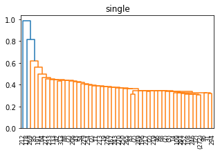

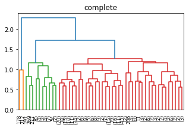

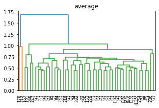

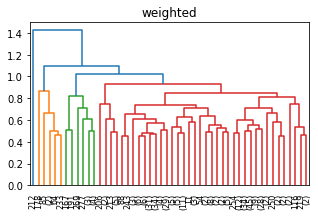

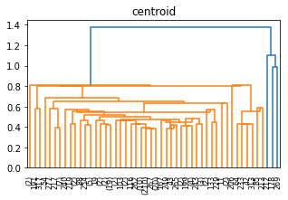

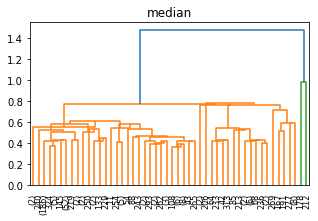

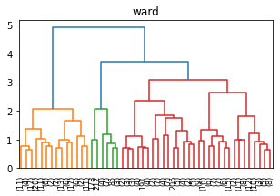

```python
for metric_ in metrics:
    Z = h.linkage(data_scaled, method=metric_, metric='euclidean')
    labels_h = h.fcluster(Z, t=3, criterion='maxclust')
    plt.figure(figsize=(5,3))
    plt.title(metric_)
    _=h.dendrogram(Z, p=50, truncate_mode='lastp')
    print(metric_, silhouette_score(data_scaled, labels_h))
```

- Манхетонские кварталы

```
single 0.5641542755098847
complete 0.4863788232305954
average 0.47052961651745373
weighted 0.32370701756252884
```

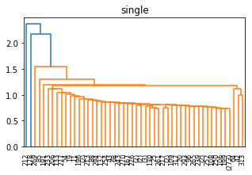

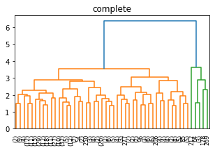

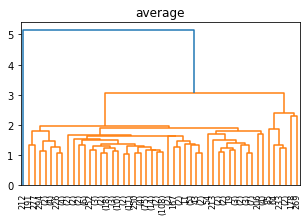

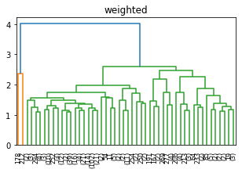

```python
metrics.pop()
metrics.pop()
metrics.pop()
for metric_ in metrics:
    Z = h.linkage(data_scaled, method=metric_, metric='cityblock')
    labels_h = h.fcluster(Z, t=3, criterion='maxclust')
    plt.figure(figsize=(5,3))
    plt.title(metric_)
    _=h.dendrogram(Z, p=50, truncate_mode='lastp')
    print(metric_, silhouette_score(data_scaled, labels_h))
```

#### Вывод:

Наиболее графически интересные результаты показал метод ward при метрике euclidean (3 кластера), complete при euclidean и median при euclidean. Для дальнейшей работы выберу метод ward, тк кластеризация выглядит лучше всего, несмотря на низкий silhouette_score)

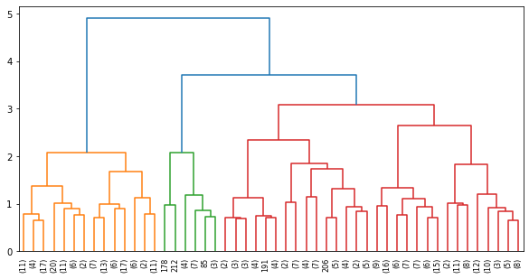

```python
Z = h.linkage(data_scaled, method='ward', metric='euclidean')
labels_h = h.fcluster(Z, t=3, criterion='maxclust')
plt.figure(figsize=(10,5))
_=h.dendrogram(Z, p=50, truncate_mode='lastp')
```

### Задание 3: DBSCAN

```python
from sklearn.cluster import DBSCAN
from sklearn.metrics.pairwise import pairwise_distances
```

С помощью эвристики подбираем параметры:

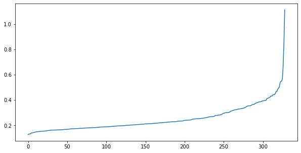

```python
plt.figure(figsize=(10, 5))
inertia = []

# сортирую расстояние
d = np.sort(pairwise_distances(data_scaled))
for dot in d:
    inertia.append(np.sort(dot)[1:5].mean())

plt.plot(range(len(inertia)), np.sort(inertia))
plt.show()
```

Самый сильный перегиб происходит в районе, где Eps = 0.5 Попробуем подобрать min_samples с помощью каменистой осыпи:

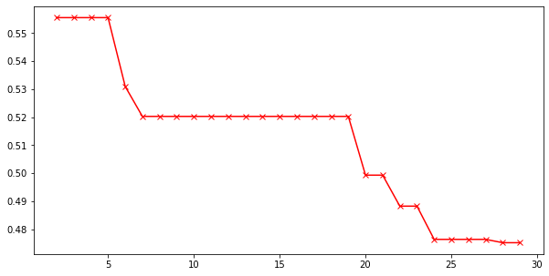

```python
plt.figure(figsize=(10, 5))
inertia = []
for i in range(2, 30):
    dbscan = DBSCAN(eps=0.5, min_samples=i)
    labels_dbscan = dbscan.fit_predict(data_scaled)
    inertia.append(silhouette_score(data_scaled, labels_dbscan))
plt.plot(range(2, 30), inertia, 'x-r')
plt.show()
```

По графику подберем параметр min_samples = 7

```python
dbscan = DBSCAN(eps=0.5, min_samples=7)
labels_dbscan = dbscan.fit_predict(data_scaled)
```

### Задание 4: K-means

```python
from sklearn.cluster import KMeans
from sklearn.metrics import adjusted_mutual_info_score, silhouette_score
```

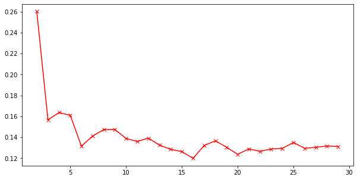

```python
plt.figure(figsize=(10, 5))
inertia = []
for i in range(2, 30):
    kmeans = KMeans(n_clusters=i, n_init=100)
    kmeans.fit(data_scaled)
    labels = kmeans.predict(data_scaled)
    inertia.append(silhouette_score(data_scaled, labels))
plt.plot(range(2, 30), inertia, 'x-r')
plt.show()
```

Методом "каменистой осыпи" выберу количество кластеров равное 4, тк далее угол получается более пологий.

```python
kmeans = KMeans(n_clusters=4, n_init=100)
kmeans.fit(data_scaled)
labels = kmeans.predict(data_scaled)
labels
```

```
array([0, 3, 0, 3, 3, 0, 0, 3, 0, 3, 1, 1, 0, 0, 3, 0, 0, 3, 0, 2, 1, 0,
       0, 0, 0, 2, 3, 0, 0, 0, 0, 1, 0, 1, 3, 0, 3, 3, 0, 0, 3, 3, 2, 1,
       0, 0, 0, 1, 0, 0, 0, 0, 3, 0, 3, 0, 0, 3, 3, 3, 3, 3, 3, 0, 2, 3,
       3, 0, 2, 1, 0, 3, 0, 3, 0, 0, 2, 1, 0, 0, 3, 1, 0, 2, 3, 2, 0, 0,
       3, 3, 0, 0, 0, 0, 0, 3, 3, 0, 3, 3, 0, 0, 0, 3, 0, 3, 1, 1, 1, 1,
       0, 0, 3, 1, 1, 0, 0, 1, 3, 0, 3, 0, 0, 0, 0, 3, 3, 0, 0, 3, 2, 0,
       1, 0, 2, 0, 0, 3, 0, 3, 3, 3, 0, 0, 3, 0, 0, 3, 0, 3, 0, 3, 3, 3,
       0, 3, 0, 3, 3, 1, 0, 1, 0, 0, 3, 0, 0, 1, 0, 1, 0, 0, 3, 0, 3, 0,
       0, 0, 2, 3, 0, 1, 3, 0, 3, 0, 0, 0, 0, 1, 3, 2, 3, 3, 1, 3, 3, 0,
       0, 1, 0, 0, 0, 0, 0, 3, 1, 0, 3, 3, 3, 1, 2, 2, 3, 1, 1, 2, 1, 0,
       1, 0, 3, 0, 1, 0, 1, 0, 0, 0, 3, 0, 0, 2, 1, 0, 2, 0, 1, 2, 0, 0,
       3, 3, 0, 0, 3, 0, 3, 3, 0, 3, 1, 0, 0, 3, 0, 3, 0, 0, 0, 2, 3, 1,
       1, 1, 0, 3, 2, 2, 1, 1, 1, 1, 1, 3, 0, 2, 0, 0, 0, 3, 0, 3, 3, 3,
       3, 3, 0, 1, 0, 0, 0, 3, 1, 3, 1, 0, 0, 3, 3, 3, 1, 1, 0, 0, 3, 1,
       0, 0, 0, 1, 0, 2, 0, 0, 0, 1, 0, 0, 0, 0, 3, 1, 0, 0, 0, 0, 0])
```

### 5. Не успела :(

```python
from sklearn.cluster import FeatureAgglomeration
```

```python
agglo = FeatureAgglomeration(n_clusters=4)
agglo.fit(X)
```

```
FeatureAgglomeration(n_clusters=4)
```

### 6. Сравнение кластеризаций:

В итоге разбиения данных разными способами кластеризации получилось следующее:

- агломиративная иерархическая кластеризация - 3 кластера
- DBSCAN - один кластер и выбросы
- K-means - 4 кластера

```python
from sklearn.metrics import davies_bouldin_score
```

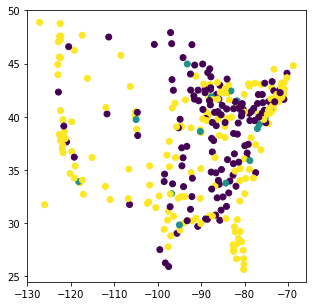

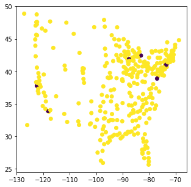

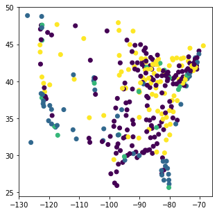

```python
all_labels = {"Иерархическая: ": labels_h,"DBSCAN: ":labels_dbscan,"K-means: ": labels}
for key in all_labels.keys():
    plt.figure(figsize=(5, 5))
    plt.scatter(x=data['Long'], y=data['Lat'], c=all_labels[key])
    plt.show()
```

По графикам видно, что кластеризации разными методами получились достаточно отличными друг от друга.

```python
for key in all_labels.keys():
    print(key, silhouette_score(data_scaled, all_labels[key]), davies_bouldin_score(data_scaled, all_labels[key]))
```

```
Иерархическая:  0.13781545274723117 1.8084471812857565
DBSCAN:  0.5202923268377728 1.0971090062790558
K-means:  0.16237972168144 1.7804644235192524
```

Самый высокий показатель silhouette_score у DBSCAN, но там выделились странные кластеры.

### 7. Выбор кластеризации:

```python
for key in all_labels:
    dif_l = set(all_labels[key])
    print(key)
    for l in dif_l:
        print(data[all_labels[key] == l], data[all_labels[key] == l].mean())
    print()
```

```
Иерархическая:
                         Place  Climate  HousingCost  HlthCare  Crime  Transp  \
2                    Albany,GA      468         7339       618    970    2531
5                Alexandria,LA      520         5819       640    727    2444
6    Allentown,Bethlehem,PA-NJ      559         8288       621    514    2881
8                   Altoona,PA      561         6191       432    399    4246
12                 Anderson,IN      530         5704       580    878    2865
..                         ...      ...          ...       ...    ...     ...
324               Worcester,MA      562         8715      1805    680    3643
325                  Yakima,WA      535         6440       317   1106    3731
326                    York,PA      540         8371       713    440    2267
327       Youngstown-Warren,OH      570         7021      1097    938    3374
328               Yuba-City,CA      608         7875       212   1179    2768

     Educ  Arts  Recreat  Econ      Long      Lat     Pop
2    2560   237      859  5250  -84.1580  31.5750  112402
5    2972   334     1018  5254  -92.4530  31.3020  135282
6    3144  2333     1117  5097  -75.4405  40.6155  635481
8    2778   256     1210  4230  -78.3950  40.5150  136621
12   2469   430      838  3370  -85.6850  40.1670  139336
..    ...   ...      ...   ...       ...      ...     ...
324  3299  1784      910  5040  -71.7950  42.2720  402918
325  2491   996     2140  4986 -120.5130  46.5950  172508
326  2903  1022      842  4946  -76.7280  39.9600  381255
327  2920  2797     1327  3894  -80.7290  41.1700  531350
328  2387   122      918  4694 -121.6220  39.1280  101979

[133 rows x 13 columns] Climate           503.488722
HousingCost      7108.624060
HlthCare          749.992481
Crime             747.390977
Transp           3313.526316
Educ             2707.526316
Arts             1237.127820
Recreat          1437.872180
Econ             4943.488722
Long              -87.906792
Lat                38.652977
Pop            196248.939850
dtype: float64
```

[output cut: 349 more lines]

```
322    4532  3112  4545     1923  6174  -75.5500  39.7470  523221

[96 rows x 13 columns] Climate           528.864583
HousingCost      8125.447917
HlthCare         1326.156250
Crime             941.010417
Transp           5386.906250
Educ             2942.208333
Arts             3372.427083
Recreat          1854.020833
Econ             5272.385417
Long              -87.654914
Lat                39.991674
Pop            460989.812500
dtype: float64
```

После просмотра каждого кластера и средних значений я выберу k-means потому что значения в столбиках ближе к срдним, а так же выше silhouette score.

### 8. Распределение кластеров территориально

Провизуализируем расположение кластеров с помощью данных о широте и долготе:

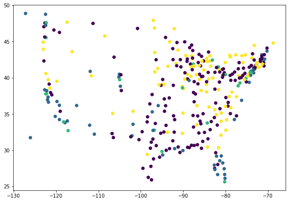

```python
plt.figure(figsize=(10, 7))
plt.scatter(x=data['Long'], y=data['Lat'], c=labels)
plt.show()
```

Кластеры довольно перемешаны географически, основная часть синего кластера раположена на северо-западе, желтая в центре и на востоке, а фиолетовй в основном на востоке. Но в целом зависимость от штатов или географического положения не наблюдаетсяю.

```python
import folium


m = folium.Map(location=[45.5236, -122.6750])
```

[output not shown]

[figure not shown]